# Customer Segmentation

Haykal Pradana

7/19/2024

## Problem Statement

Marketing would like to increase email campaign engagement by segmenting the customer-base using their buying habits.

## Solution Summary

The data science team has identified 4 customer segments. The 4 customer segments were given descriptions based on the customer’s top product purchases.

1. *Segment 1 Preference:* Mountain Bikes, Above $3,200 (Premium Models)
2. *Segment 2 Preference:* Road Bikes, Above $3,200 (Premium Models)
3. *Segment 3 Preference:* Road Bikes, Below $3,200 (Economical Models)
4. *Segment 4 Preference:* Both Road and Mountain, Below $3,200 (Economical Models)

## Customer Preferences

### Heat Map

Our customer-base consists of 30 bike shops. Several customers have purchasing preference for Road or Mountain Bikes based on the proportion of bikes purchased by category_1 and category_2.

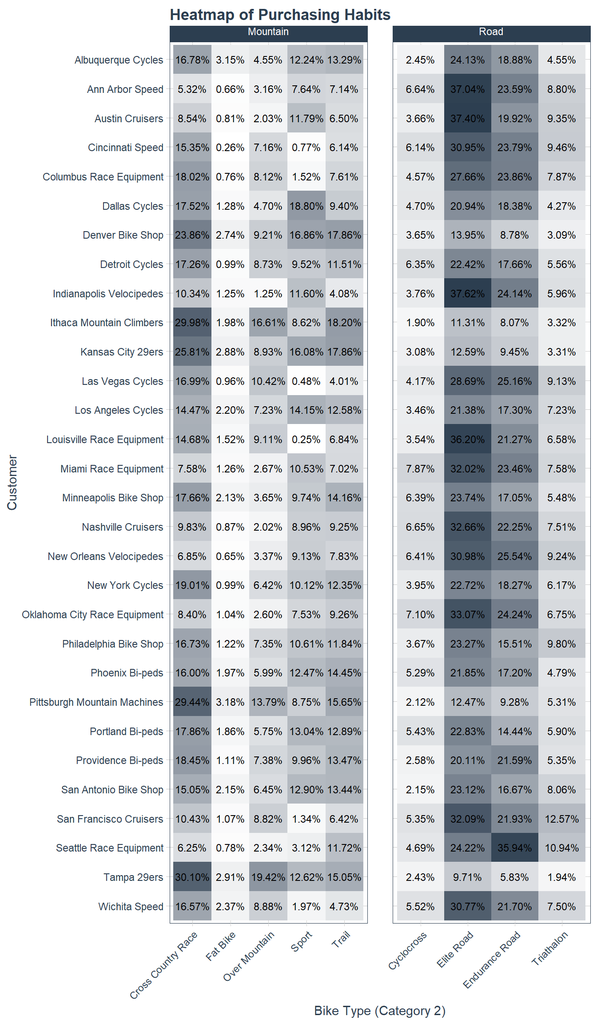

### Customer Segmentation

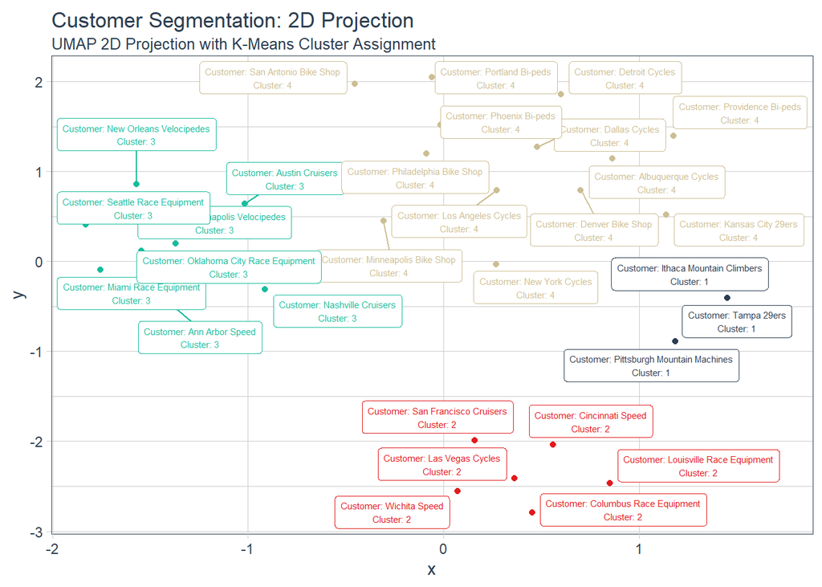

### Customer Preferences By Segment

The 4 customer segments were given descriptions based on the customer’s top product purchases.

1. *Segment 1 Preference:* Mountain Bikes, Above $3,200 (Premium Models)
2. *Segment 2 Preference:* Road Bikes, Above $3,200 (Premium Models)
3. *Segment 3 Preference:* Road Bikes, Below $3,200 (Economical Models)
4. *Segment 4 Preference:* Both Road and Mountain, Below $3,200 (Economical Models)

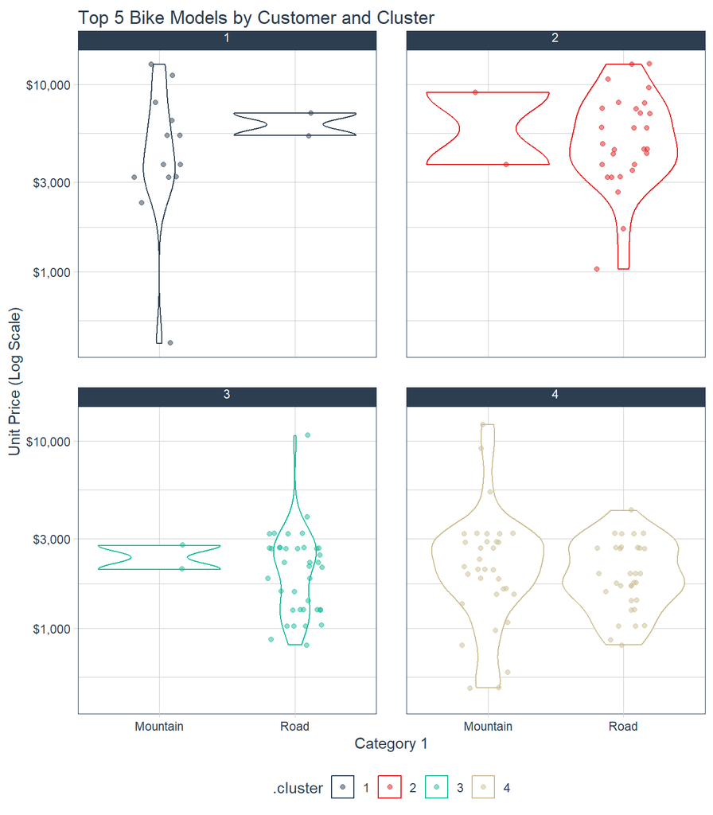